# Chapter 4 - MSDM Culminating Experience Project

AI_Impatience Effect

Author

Group 6: Monica; Kristie; Michael

Published

May 5, 2025

CHAPTER 4 AO #1

# 1 Data preparation: downloaded data from Qualtrics into SPSS.

```r
# Load required libraries

library(tidyverse)   # for data wrangling and visualization
library(gtsummary)   # for summary tables
library(gt)          # for formatting gt tables
library(sjPlot)


library(haven)
library(janitor)
library(labelled)

library(naniar)
library(GGally)

library(gtExtras)
library(dplyr)
library(readxl)
```

# 2 Data Import and Data Cleaning: Examine questionnaire responses for integrity/ attention_check and exclude low-quality responses.

```r
# Read the data
raw_data <- read_sav("~/Downloads/IBM student project_ AI patience (AI-designed video)-timesaving_April 8, 2025_11.20_cleaned.sav")

nrow(raw_data)
```

```
[1] 155
```

```r
#df_raw <- read_excel("~/Downloads/IBM student project_ AI patience (AI-designed video)-timesaving_April 8, 2025_11.20_cleaned.xlsx")

# Filter out incomplete responses and speeders
df_clean <- raw_data %>%
  filter(Progress >= 50,            # at least half responses completed
         Duration__in_seconds_ >= 50)  # remove extremely fast completions (<50s)

# Check number of responses remaining
nrow(df_clean)
```

```
[1] 155
```

```r
# SHOULD be 155 observations
```

# 3 Recode and Structure Data:

Create the new binary variable AI_Condition = 1 for AI-created video and AI_Condition = 0 for Human-created video.

## 3.1 Define experimental condition: Create a binary variable AI_Condition indicating the video source (1 = AI-created video, 0 = Human-created video) based on the survey flow flags. We then drop the original flag columns for cleanliness.

Select relevant variables: For AO#1, the key measures are the Likert-scale statements about reward timing preferences. According to the questionnaire, these are: “I would rather eat the cheese now.” “I would rather eat the cheese right away.” “I would rather eat the cheese in the distant future.” “I would rather wait and eat it later.”

We identify the corresponding columns in the data and rename them for clarity.

```r
# Identify and rename the Likert item columns for reward preference

library(dplyr)

AO1_data <- df_clean %>%
  select(FL_3_DO_AI_createdvideo, Q3.0, Q4.0, Q5, Q6, Q7.1, Q7.2) %>%
  mutate(AI_Condition = if_else(FL_3_DO_AI_createdvideo == "1", 1, 0, missing=0)) %>%     select (-FL_3_DO_AI_createdvideo) %>%
  rename(
    Sooner_Rewards1    = Q3.0, # "I would rather eat the cheese now."
    Sooner_Rewards2    = Q4.0, # "I would rather eat the cheese right away."
    Later_Rewards1        = Q5,   # "I would rather eat the cheese in the distant future."
    Later_Rewards2        = Q6,    # "I would rather wait and eat it later."
    Age                  = Q7.1,  # What is your age?"
    Gender               = Q7.2  # What is your gender?"
  ) %>%
  drop_na()

glimpse(AO1_data)
```

```
Rows: 153
Columns: 7
$ Sooner_Rewards1 <dbl+lbl>  6,  6, 11,  6,  3,  1, 11,  3,  1,  3,  6,  6,  8…
$ Sooner_Rewards2 <dbl+lbl>  6,  6, 11,  7,  3,  1, 11,  3,  1,  3,  7,  6,  8…
$ Later_Rewards1  <dbl+lbl>  6,  6, 11,  3,  7,  7,  8,  7,  6,  7,  7,  6,  2…
$ Later_Rewards2  <dbl+lbl>  6,  6,  1,  6,  8,  7,  3,  7,  6,  7,  6,  6,  2…
$ Age             <chr> "21", "25", "21", "20", "20", "20", "21", "20", "21", …
$ Gender          <dbl+lbl> 1, 1, 2, 1, 1, 1, 2, 1, 2, 2, 1, 1, 2, 2, 2, 1, 1,…
$ AI_Condition    <dbl> 0, 1, 1, 0, 1, 0, 1, 0, 0, 1, 0, 1, 1, 1, 0, 0, 1, 1, …
```

```r
summary(AO1_data)
```

```
 Sooner_Rewards1  Sooner_Rewards2  Later_Rewards1   Later_Rewards2
 Min.   : 1.000   Min.   : 1.000   Min.   : 1.000   Min.   : 1.000
 1st Qu.: 2.000   1st Qu.: 2.000   1st Qu.: 6.000   1st Qu.: 6.000
 Median : 6.000   Median : 3.000   Median : 6.000   Median : 6.000
 Mean   : 4.673   Mean   : 4.523   Mean   : 6.131   Mean   : 6.144
 3rd Qu.: 7.000   3rd Qu.: 7.000   3rd Qu.: 7.000   3rd Qu.: 8.000
 Max.   :11.000   Max.   :11.000   Max.   :11.000   Max.   :11.000
     Age                Gender       AI_Condition
 Length:153         Min.   :1.000   Min.   :0.0000
 Class :character   1st Qu.:1.000   1st Qu.:0.0000
 Mode  :character   Median :2.000   Median :0.0000
                    Mean   :1.503   Mean   :0.4967
                    3rd Qu.:2.000   3rd Qu.:1.0000
                    Max.   :2.000   Max.   :1.0000
```

```r
AO1_data_pref <- AO1_data %>%
  mutate(
    "Immediate_Reward_Preference" = (Sooner_Rewards1 + Sooner_Rewards2) / 2,
    "Delayed_Reward_Preference"   =(Later_Rewards1 + Later_Rewards2) / 2
  ) %>%
  select (-Sooner_Rewards1, -Sooner_Rewards2, -Later_Rewards1, -Later_Rewards2)

glimpse(AO1_data_pref)
```

```
Rows: 153
Columns: 5
$ Age                         <chr> "21", "25", "21", "20", "20", "20", "21", …
$ Gender                      <dbl+lbl> 1, 1, 2, 1, 1, 1, 2, 1, 2, 2, 1, 1, 2,…
$ AI_Condition                <dbl> 0, 1, 1, 0, 1, 0, 1, 0, 0, 1, 0, 1, 1, 1, …
$ Immediate_Reward_Preference <dbl> 6.0, 6.0, 11.0, 6.5, 3.0, 1.0, 11.0, 3.0, …
$ Delayed_Reward_Preference   <dbl> 6.0, 6.0, 6.0, 4.5, 7.5, 7.0, 5.5, 7.0, 6.…
```

```r
summary(AO1_data_pref)
```

```
     Age                Gender       AI_Condition
 Length:153         Min.   :1.000   Min.   :0.0000
 Class :character   1st Qu.:1.000   1st Qu.:0.0000
 Mode  :character   Median :2.000   Median :0.0000
                    Mean   :1.503   Mean   :0.4967
                    3rd Qu.:2.000   3rd Qu.:1.0000
                    Max.   :2.000   Max.   :1.0000
 Immediate_Reward_Preference Delayed_Reward_Preference
 Min.   : 1.000              Min.   : 1.000
 1st Qu.: 2.000              1st Qu.: 5.000
 Median : 5.000              Median : 6.500
 Mean   : 4.598              Mean   : 6.137
 3rd Qu.: 6.500              3rd Qu.: 7.000
 Max.   :11.000              Max.   :11.000
```

```r
AO1_data_final <- AO1_data_pref %>%
  mutate(Preference_Score = (Immediate_Reward_Preference + (8 - Delayed_Reward_Preference)) / 2) %>%
  mutate(AI_Condition = as.factor(AI_Condition)) %>%
  select (-Immediate_Reward_Preference, -Delayed_Reward_Preference)


head(AO1_data_final)
```

```
# A tibble: 6 × 4
  Age   Gender     AI_Condition Preference_Score
  <chr> <dbl+lbl>  <fct>                   <dbl>
1 21    1 [Male]   0                        4
2 25    1 [Male]   1                        4
3 21    2 [Female] 1                        6.5
4 20    1 [Male]   0                        5
5 20    1 [Male]   1                        1.75
6 20    1 [Male]   0                        1
```

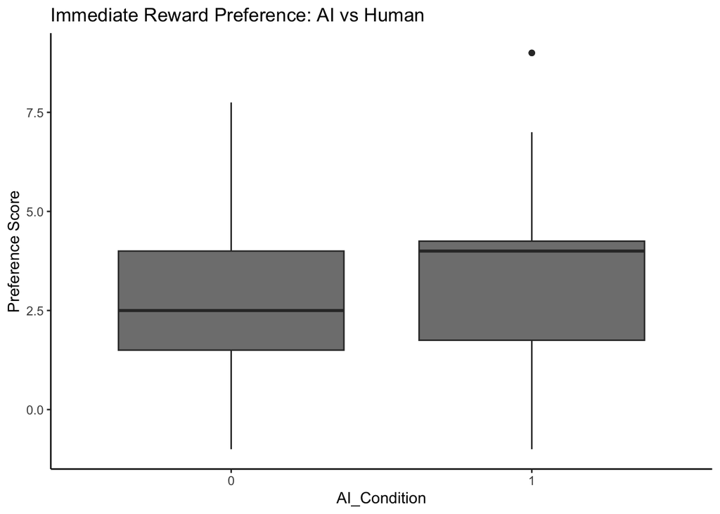

```r
library(ggplot2)

ggplot(AO1_data_final, aes(x = AI_Condition, y = Preference_Score, fill = AI_Condition)) +
  geom_boxplot() +
  scale_fill_manual(values = c(
    Human = "#E69F00",   # golden
    AI    = "#D55E00"    # reddish‐orange
  )) +
  labs(
    title = "Immediate Reward Preference: AI vs Human",
    x     = "AI_Condition",
    y     = "Preference Score"
  ) +
  theme_classic()
```

# 4 Create binary reward choice indicators:

Next, we create a binary indicator for high immediacy preference “AI_Impatience”

Finally, we define Consumer_Impatience such that 1 denotes a consumer who favors immediate consumption more than delayed (i.e., a higher immediate preference relative to delayed preference).

Preference_Score > 3.5 means “Impatience” = 1 and Preference_Score < 3.5 means “Impatience” = 0

```r
AO1_Impatience <- AO1_data_final %>%
  mutate(
    Consumer_Impatience = case_when(
   Preference_Score >= 3.5 & Preference_Score <= 7 ~ 1,
   Preference_Score >= 1 & Preference_Score <= 3.5 ~ 0, TRUE ~ NA_real_)) %>%
   mutate(Consumer_Impatience = as.factor(Consumer_Impatience)) %>%
   mutate(Gender = as_factor(Gender)) %>%
   mutate (Gender = if_else(Gender == 1, 1L, 0L)) %>%
   mutate(Gender = factor(
      Gender,
      levels = c(0L, 1L),
      labels = c("Female", "Male"))) %>%
   mutate(Age = as.numeric(Age))

head(AO1_Impatience)
```

```
# A tibble: 6 × 5
    Age Gender AI_Condition Preference_Score Consumer_Impatience
  <dbl> <fct>  <fct>                   <dbl> <fct>
1    21 Female 0                        4    1
2    25 Female 1                        4    1
3    21 Female 1                        6.5  1
4    20 Female 0                        5    1
5    20 Female 1                        1.75 0
6    20 Female 0                        1    0
```

```r
glimpse(AO1_Impatience)
```

```
Rows: 153
Columns: 5
$ Age                 <dbl> 21, 25, 21, 20, 20, 20, 21, 20, 21, 20, 20, 21, 19…
$ Gender              <fct> Female, Female, Female, Female, Female, Female, Fe…
$ AI_Condition        <fct> 0, 1, 1, 0, 1, 0, 1, 0, 0, 1, 0, 1, 1, 1, 0, 0, 1,…
$ Preference_Score    <dbl> 4.00, 4.00, 6.50, 5.00, 1.75, 1.00, 6.75, 2.00, 1.…
$ Consumer_Impatience <fct> 1, 1, 1, 1, 0, 0, 1, 0, 0, 0, 1, 1, 1, 1, 0, 1, 1,…
```

# 5 Create a descriptive summary table comparing conditions (AI vs. Human)

```r
desc_table <- AO1_Impatience %>%
  tbl_summary(
    by = AI_Condition,                  # compare summary by video condition
    statistic = all_continuous() ~ "{mean} ({sd})",  # mean and SD for continuous variables
    missing = "no"                      # assume no missing values after cleaning
  ) %>%
  add_overall() %>%                    # add overall column
  as_gt()                              # convert to a gt table for nicer formatting

# Render the descriptive summary table:
desc_table
```

| **Characteristic** | **Overall** N = 153<sup>1</sup> | **0** N = 77<sup>1</sup> | **1** N = 76<sup>1</sup> |
| --- | --- | --- | --- |
| Age | 22.3 (5.4) | 21.2 (3.6) | 23.4 (6.6) |
| Gender |  |  |  |
| Female | 153 (100%) | 77 (100%) | 76 (100%) |
| Male | 0 (0%) | 0 (0%) | 0 (0%) |
| Preference_Score | 3.23 (2.08) | 2.96 (2.07) | 3.50 (2.06) |
| Consumer_Impatience |  |  |  |
| 0 | 61 (45%) | 37 (54%) | 24 (36%) |
| 1 | 74 (55%) | 31 (46%) | 43 (64%) |

<sup>1</sup> Mean (SD); n (%)

# 6 Final AO#1 dataset: We save or store the resulting cleaned and recoded data as AI_Impatience_Data for further analysis.

```r
AO1_Impatience_Data <- AO1_Impatience
# Save the tidy dataset (if needed externally) before proceeding with logistic regression
write_csv(AO1_Impatience_Data, "AO1_Impatience_Data.csv")

head(AO1_Impatience_Data)
```

```
# A tibble: 6 × 5
    Age Gender AI_Condition Preference_Score Consumer_Impatience
  <dbl> <fct>  <fct>                   <dbl> <fct>
1    21 Female 0                        4    1
2    25 Female 1                        4    1
3    21 Female 1                        6.5  1
4    20 Female 0                        5    1
5    20 Female 1                        1.75 0
6    20 Female 0                        1    0
```

# 7 Consumer Impatience by AI Condition bar plot

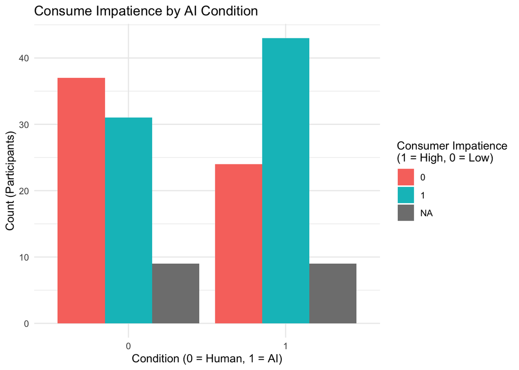

```r
ggplot(AO1_Impatience_Data, aes(x = AI_Condition, fill = as.factor(Consumer_Impatience))) +
  geom_bar(position = "dodge") +
  labs(
    title = "Consume Impatience by AI Condition",
    x     = "Condition (0 = Human, 1 = AI)",
    y     = "Count (Participants)",
    fill = "Consumer Impatience\n(1 = High, 0 = Low)"
  ) +
  theme_minimal()
```